# Week 4, Meeting 2

# More Numpy

## Read a little data

```python
import numpy as np
import matplotlib.pyplot as plt

np.set_printoptions(suppress=True, linewidth=120, precision=3)

ames = np.loadtxt("ames_numeric.txt")

print(type(ames), ames.shape)
```

```
<class 'numpy.ndarray'> (1121, 20)
```

## Ames Data

This is the numeric data from the Ames house prices dataset, (https://www.kaggle.com/datasets/shashanknecrothapa/ames-housing-dataset) a classic dataset for data analysis. This subset (numeric variables, missing deleted) of the original dataset contains 1121 rows and 20 features. The features are as follows:

```
https://jse.amstat.org/v19n3/decock/DataDocumentation.txt
 [1] "LotFrontage"
 [2] "LotArea"
 [3] "OverallQual"
 [4] "YearBuilt"
 [5] "YearRemodAdd"
 [6] "MasVnrArea"
 [7] "BsmtFinSF1"
 [8] "TotalBsmtSF"
 [9] "1stFlrSF"
[10] "2ndFlrSF"
[11] "GrLivArea"
[12] "FullBath"
[13] "TotRmsAbvGrd"
[14] "Fireplaces"
[15] "GarageYrBlt"
[16] "GarageCars"
[17] "GarageArea"
[18] "WoodDeckSF"
[19] "OpenPorchSF"
[20] "SalePrice"   (target)
```

## The data in NumPy

- The data values and the target are stored in arrays of type `numpy.ndarray`
- In the data array, each row corresponds to a home sale, or an observation or a sample.
- Each column corresponds to a feature that is described previously.
- Recall that a `numpy.ndarray` is not just multi-dimensional array or a matrix in Python. It object-oriented origins give us methods etc.

## Take a look at the data

Here are the first 5 rows (samples), each of which consists of 20 feature values,

```python
print(ames[0:5, :])
```

```
[[    65.   8450.      7.   2003.   2003.    196.    706.    856.    856.    854.   1710.      2.      8.      0.
    2003.      2.    548.      0.     61. 208500.]
 [    80.   9600.      6.   1976.   1976.      0.    978.   1262.   1262.      0.   1262.      2.      6.      1.
    1976.      2.    460.    298.      0. 181500.]
 [    68.  11250.      7.   2001.   2002.    162.    486.    920.    920.    866.   1786.      2.      6.      1.
    2001.      2.    608.      0.     42. 223500.]
 [    60.   9550.      7.   1915.   1970.      0.    216.    756.    961.    756.   1717.      1.      7.      1.
    1998.      3.    642.      0.     35. 140000.]
 [    84.  14260.      8.   2000.   2000.    350.    655.   1145.   1145.   1053.   2198.      2.      9.      1.
    2000.      3.    836.    192.     84. 250000.]]
```

## Some basic statistics

- We can use axis=0 to help us generate statistics (recall ames is 1121,20)
- Not a ton of descriptive statistics (a limitation) - but all of the basics - https://numpy.org/doc/stable/reference/routines.statistics.html

```python
print(f'The mean of each column is \n {ames.mean(axis=0)}')
print(f'The standard deviation of each column is \n {ames.std(axis=0)}')
```

```
The mean of each column is
 [    70.665  10122.956      6.212   1972.265   1985.683    108.488    438.4     1077.115   1173.584    353.259
   1531.411      1.581      6.576      0.604   1978.4        1.879    502.955     92.61      46.13  185506.153]
The standard deviation of each column is
 [   24.256  8125.676     1.38     30.954    21.017   189.416   468.176   445.458   386.002   438.366   523.49
     0.55      1.59      0.632    25.811     0.654   191.158   121.814    64.361 82962.131]
```

## (details) Indexing & Slicing

- If you know how to index and slice a Python list, you can index and slice NumPy arrays
- Just remember that typically you are working with multiple dimensions and will need a comma to separate them.

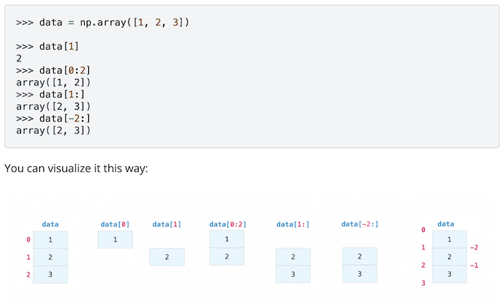

## Indexing & Slicing (cont’d)

- In addition to generating slices, you can also filter.

```python
print(f'multidimensional slice example: ames[2, :] result:\n {ames[2, :]}')
print(f'multidimensional slice example: ames[: , 3] result:\n {ames[: , 3]}')
print(f'multidimensional slice example: ames[1:3, 2:4] result:\n {ames[1:3, 2:4]}')
print(f'filter example: ames[ames > 250000] result:\n {ames[ames > 250000]}')
```

```
multidimensional slice example: ames[2, :] result:
 [    68.  11250.      7.   2001.   2002.    162.    486.    920.    920.    866.   1786.      2.      6.      1.
   2001.      2.    608.      0.     42. 223500.]
multidimensional slice example: ames[: , 3] result:
 [2003. 1976. 2001. ... 1941. 1950. 1965.]
multidimensional slice example: ames[1:3, 2:4] result:
 [[   6. 1976.]
 [   7. 2001.]]
filter example: ames[ames > 250000] result:
 [307000. 345000. 279500. 325300. 256300. 306000. 277500. 309000. 319900. 385000. 438780. 317000. 260000. 383970.
 259500. 320000. 260000. 372402. 269500. 254900. 320000. 412500. 325624. 501837. 475000. 286000. 315000. 311872.
 274900. 252678. 386250. 290000. 403000. 318000. 262500. 276000. 266000. 290000. 415298. 267000. 295000. 305900.
 360000. 375000. 260000. 270000. 260000. 342643. 354000. 301000. 324000. 284000. 377426. 266000. 437154. 318061.
 280000. 340000. 394432. 426000. 258000. 280000. 339750. 315000. 555000. 280000. 263435. 440000. 251000. 380000.
 297000. 326000. 374000. 289000. 402861. 265000. 315750. 446261. 315000. 263000. 255500. 284000. 325000. 316600.
 253293. 325000. 369900. 451950. 319000. 275000. 359100. 314813. 305000. 264561. 274000. 345000. 370878. 350000.
 402000. 423000. 257500. 372500. 285000. 392000. 755000. 335000. 312500. 361919. 254000. 341000. 320000. 265979.
 260400. 275500. 290000. 337000. 270000. 264132. 538000. 395000. 269790. 485000. 582933. 385000. 250580. 303477.
 350000. 328900. 268000. 611657. 255000. 285000. 320000. 253000. 270000. 336000. 395192. 348000. 337500. 293077.
 315500. 262280. 278000. 556581. 255000. 335000. 328000. 252000. 325000. 274725. 280000. 318000. 259000. 424870.
 625000. 285000. 392500. 745000. 262000. 271900. 290000. 367294. 265900. 301500. 378500. 278000. 281000. 290000.
 325000. 335000. 333168. 295493. 256000. 283463. 410000. 315000. 260000. 274300. 377500. 281213. 282922. 275000.
 257000. 271000. 394617. 310000. 287090. 266500.]
```

Reference: https://numpy.org/doc/stable/user/absolute_beginners.html#indexing-and-slicing

# Activity

## What to do in your group (5-10 minutes)

Grab a team photo, and then

- Please check your team
  - does everyone have pandas and matplotlib working?
  - extra - you might install scipy
  - pretty much anything Python related that your team can agree upon
  - the most important lesson to come away with from attending is how to interact with your classmates
  - Maybe say hello to someone new today

## Regression Example

The target value is typically the last column “SalePrice” and the predictors are the other variables such as “OverallQual” and “Gr Liv Area”

```python
# X = keep all rows, all columns except the last one note the :
ames_data = ames[:, :-1]    # shape (1121, 19)
print(f'The shape of ames_data is: {ames_data.shape}')

# y = keep all rows, only the last column "SalePrice"
ames_target = ames[:, -1]     # shape (1121,)
print(f'The shape of ames_target is: {ames_target.shape}')
```

```
The shape of ames_data is: (1121, 19)
The shape of ames_target is: (1121,)
```

## The mathematical notation for OLS

The OLS solution is given by:

$$\widehat{\beta} = (X^T X)^{-1} X^T y$$

Where:

- ( X ) is the **design matrix** (matrix of features)
- ( y ) is the **target vector**
- ( $\widehat{\beta}$ ) is the **vector of estimated regression coefficients**

## Translated to Numpy

- `X.T` = transpose of the matrix `X` ( ( $X^T$ ))
- `np.dot(X.T, X)` = matrix product ( $X^T X$ )
- `np.linalg.inv(...)` = matrix inverse ( ($X^T X)^{-1}$ )
- `np.dot(..., X.T)` = ( $(X^T X)^{-1} X^T$ )
- `np.dot(..., y)` = finally multiplying by ( y ), gives us ( $\widehat{\beta}$ )

Translating a matrix formula into Python/NumPy code.

## But use…

`np.linalg.lstsq(X, y)[0]`

- This solution is numerically more stable than computing the matrix inverse directly
- Computing the matrix inverse ( $(X^T X)^{-1}$ ) with an ill-conditioned (close to singular) $X$ makes ( $(X^T X)$ ) worse and computing an inverse (nearly un-invertible) will magnify small errors
- Solution is to solve the system using QR decomposition or Singular Value Decomposition (SVD)

## Full model (no intercept term)

- NumPy default is no intercept (R’s default lm has intercept)
- the typical regression interpretations no longer apply with no intercept (this is here to show you the defaults)

```python
X = ames_data
y = ames_target

# not recommended but it is the math in textboks
beta_not_advised = np.linalg.inv(np.dot(X.T, X)).dot(np.dot(X.T, y))
print("Not advised version: \n", beta_not_advised)

# Least squares solution (is stable)
beta_lstsq = np.linalg.lstsq(X, y)[0]
print("Least squares no intercept: \n", beta_lstsq)
```

```
Not advised version:
 [  -45.328     0.634 24536.128   119.514   116.068    31.159    19.362     9.697     8.764     6.703    21.37
  5289.538  1466.212  5608.279  -291.224 18698.836    22.096    36.841    24.913]
Least squares no intercept:
 [  -45.328     0.634 24536.128   119.514   116.068    31.159    19.362     9.697     8.764     6.703    21.37
  5289.538  1466.212  5608.279  -291.224 18698.836    22.096    36.841    24.913]
```

## Least squares solution

- actually returns a tuple, the coefficients $\widehat\beta$ are [0]
- The sum of squared residuals (SSR) is [1]
- rank of matrix X is [2] ours is 19 which means no collinearity in our regressors
- Singular values [3] values near zero would indicate singularity or ill-conditioning relating to stability of our estimates

```python
est_object = np.linalg.lstsq(X, y)
print(type(est_object))
est_object
```

```
<class 'tuple'>
```

```
(array([  -45.328,     0.634, 24536.128,   119.514,   116.068,    31.159,    19.362,     9.697,     8.764,     6.703,
           21.37 ,  5289.538,  1466.212,  5608.279,  -291.224, 18698.836,    22.096,    36.841,    24.913]),
 array([1.689e+12]),
 np.int32(19),
 array([449227.094,  81427.957,  19990.822,  19321.37 ,  11906.281,   6225.646,   5623.717,   4843.079,   3854.53 ,
          1952.509,    796.106,    671.436,    525.437,    359.168,     30.636,     28.761,     17.551,     12.866,
            10.622]))
```

## (aside) How to achieve stability

`np.linalg.lstsq` solves the system using QR decomposition or **Singular Value Decomposition (SVD)**:

$$X = QR$$

or

$$X = U \Sigma V^T$$

instead of simply inverting a matrix which is sensitive to small changes in the input data and to roundoff errors.

## How to add an intercept

```python
intercept = np.ones((len(y), 1))  # column of 1s
print("The intercept: \n", intercept[0:5])

# Add as the first column
X_with_intercept = np.hstack((intercept, X))
print()
print("X_with_intercept:\n"  , X_with_intercept[0:5, 0:4])
```

```
The intercept:
 [[1.]
 [1.]
 [1.]
 [1.]
 [1.]]

X_with_intercept:
 [[    1.    65.  8450.     7.]
 [    1.    80.  9600.     6.]
 [    1.    68. 11250.     7.]
 [    1.    60.  9550.     7.]
 [    1.    84. 14260.     8.]]
```

## np.hstack and np.vstack

- In R, you might combine vectors, matrices, data frames with rbind() (for rows) or cbind() (for columns).
- In NumPy, use `np.hstack` for stacking arrays horizontally (column-wise) and `np.vstack` for stacking arrays vertically

```python
import numpy as np

a = np.array([1, 2, 3])
b = np.array([4, 5, 6])
ones = np.ones(2)

# Reshape to 2D first
a2 = a.reshape(1, 3)
b2 = b.reshape(1, 3)
ones2 = ones.reshape(2,1)

v = np.vstack((a2, b2))
h = np.hstack((ones2, v))

print(f'shape: {v.shape} and result:')
print(v)
print(f'shape: {h.shape} and result:')
print(h)
```

```
shape: (2, 3) and result:
[[1 2 3]
 [4 5 6]]
shape: (2, 4) and result:
[[1. 1. 2. 3.]
 [1. 4. 5. 6.]]
```

## Estimate the model

- NumPy result is barebones

```python
# Least squares solution (stable)
beta_lstsq_with_intercept = np.linalg.lstsq(X_with_intercept, y)[0]
print("Least squares estimates:\n", beta_lstsq_with_intercept)
```

```
Least squares estimates:
 [-1033750.289      -27.059        0.698    21067.115      168.221      400.83        31.042       18.263        9.483
        5.581        2.608       30.124    -1204.386     2384.926     7267.554      -89.063    15228.042       13.48
       26.938       10.517]
```

## Customize it

- But Python results are extremely customizable

```python
var_names = ['intercept', 'LotFrontage', 'LotArea', 'OverallQual', 'YearBuilt', 'YearRemodAdd', 'MasVnrArea', 'BsmtFinSF1', 'TotalBsmtSF', '1stFlrSF', '2ndFlrSF', 'GrLivArea', 'FullBath', 'TotRmsAbvGrd', 'Fireplaces', 'GarageYrBlt', 'GarageCars', 'GarageArea', 'WoodDeckSF ', 'OpenPorchSF', 'SalePrice']

print(f"{'Variable':<15} {'Estimate':>12}")
print('-' * 28)

for name, value in zip(var_names, beta_lstsq_with_intercept):
    print(f"{name:<15} {value:12.3f}")
```

```
Variable            Estimate
----------------------------
intercept       -1033750.289
LotFrontage          -27.059
LotArea                0.698
OverallQual        21067.115
YearBuilt            168.221
YearRemodAdd         400.830
MasVnrArea            31.042
BsmtFinSF1            18.263
TotalBsmtSF            9.483
1stFlrSF               5.581
2ndFlrSF               2.608
GrLivArea             30.124
FullBath           -1204.386
TotRmsAbvGrd        2384.926
Fireplaces          7267.554
GarageYrBlt          -89.063
GarageCars         15228.042
GarageArea            13.480
WoodDeckSF            26.938
OpenPorchSF           10.517
```

## Easy formatting

| Symbol | Alignment | Example |
| --- | --- | --- |
| < | Left | f”{‘hello’:<5}” → ‘hello’ |
| > | Right | f”{‘hello’:>5}” → ’ hello’ |
| ^ | Center | f”{‘hello’:^5}” → ’ hello ’ |

## recall zip()

- `zip()` is a built-in function https://docs.python.org/3/library/functions.html#zip
- from their documentation: Iterate over several iterables in parallel, producing tuples with an item from each one.
- so just pairing the variable names with their estimates

## Compute the predicted values

- We want the residuals, first compute the predicted y

$$\text{Residuals} = y - \widehat{y} = y - X \beta$$

```python
# Compute the predicted values y_hat
y_hat = np.dot(X_with_intercept, beta_lstsq_with_intercept)

print(f'y_hat is {type(y_hat)} with shape: {y_hat.shape}')
print(f'a look at the first 5 y_hats:')
print(y_hat[0:5])
```

```
y_hat is <class 'numpy.ndarray'> with shape: (1121,)
a look at the first 5 y_hats:
[220044.319 184388.665 222676.852 200230.301 300812.133]
```

## Compute the residuals

```python
# Compute the residuals

residuals = y - y_hat

print(f'residuals is {type(residuals)} with shape: {residuals.shape}')
print(f'a look at the first 5')
print(residuals[0:5])
```

```
residuals is <class 'numpy.ndarray'> with shape: (1121,)
a look at the first 5
[-11544.319  -2888.665    823.148 -60230.301 -50812.133]
```

## Compute the MSE

- MSE - the mean squared error

```python
# Compute the variance of the error (mean squared error)
n = y.shape[0]
p = X_with_intercept.shape[1]  # number of parameters (include intercept)
MSE = ((residuals**2).sum()) / (n - p)  # Mean squared error (variance of error)

print(f'n is {n}, p is {p}, MSE is {round(MSE,3)}')
```

```
n is 1121, p is 20, MSE is 1480623267.516
```

## and the SEs for your coefficients

```python
# Compute the standard error for each coefficient including intercept
XtX_inv = np.linalg.inv(np.dot(X_with_intercept.T, X_with_intercept))

# (X^T X)^-1
standard_errors = np.sqrt(np.diagonal(XtX_inv) * MSE)
print(f'The SEs are\n {standard_errors}')
```

```
The SEs are
 [164183.188     58.653      0.162   1462.975     77.103     78.515      7.254      3.089      5.366     29.44
     28.867     28.724   3221.932   1345.827   2216.989     93.946   3571.221     12.565     10.206     19.953]
```

## Some stats

- Once we have the SEs, we can do many things
- Here, confidence intervals instead of p-values

```python
# Compute confidence intervals (95% CI) for each coefficient
z_score = 1.96  # For 95% confidence
lower_bound = beta_lstsq_with_intercept - z_score * standard_errors
upper_bound = beta_lstsq_with_intercept + z_score * standard_errors

print(f'lower_bound is {lower_bound.shape}')
print(lower_bound)
print(f'upper_bound is {upper_bound.shape}')
print(upper_bound)
```

```
lower_bound is (20,)
[-1355549.337     -142.019        0.381    18199.685       17.099      246.942       16.824       12.209       -1.034
      -52.121      -53.971      -26.176    -7519.372     -252.895     2922.255     -273.196     8228.448      -11.148
        6.934      -28.591]
upper_bound is (20,)
[-711951.24       87.901       1.016   23934.545     319.344     554.719      45.261      24.318      20.
      63.282      59.187      86.423    5110.6      5022.748   11612.852      95.07    22227.635      38.107
      46.943      49.624]
```

## But format it

```python
# Format the results
print(f"{'Variable':<15} {'Estimate':>12} {'Standard Error':>15} {'Lower CI':>12} {'Upper CI':>12}")
print('-' * 70)

for name, beta, se, lb, ub in zip(var_names, beta_lstsq_with_intercept, standard_errors, lower_bound, upper_bound):
    print(f"{name:<15} {beta:12.3f} {se:15.3f} {lb:12.3f} {ub:12.3f}")

print('-' * 70)
```

```
Variable            Estimate  Standard Error     Lower CI     Upper CI
----------------------------------------------------------------------
intercept       -1033750.289      164183.188 -1355549.337  -711951.240
LotFrontage          -27.059          58.653     -142.019       87.901
LotArea                0.698           0.162        0.381        1.016
OverallQual        21067.115        1462.975    18199.685    23934.545
YearBuilt            168.221          77.103       17.099      319.344
YearRemodAdd         400.830          78.515      246.942      554.719
MasVnrArea            31.042           7.254       16.824       45.261
BsmtFinSF1            18.263           3.089       12.209       24.318
TotalBsmtSF            9.483           5.366       -1.034       20.000
1stFlrSF               5.581          29.440      -52.121       63.282
2ndFlrSF               2.608          28.867      -53.971       59.187
GrLivArea             30.124          28.724      -26.176       86.423
FullBath           -1204.386        3221.932    -7519.372     5110.600
TotRmsAbvGrd        2384.926        1345.827     -252.895     5022.748
Fireplaces          7267.554        2216.989     2922.255    11612.852
GarageYrBlt          -89.063          93.946     -273.196       95.070
GarageCars         15228.042        3571.221     8228.448    22227.635
GarageArea            13.480          12.565      -11.148       38.107
WoodDeckSF            26.938          10.206        6.934       46.943
OpenPorchSF           10.517          19.953      -28.591       49.624
----------------------------------------------------------------------
```

## R-squared (Coefficient of Determination)

R-squared tells you the proportion of variance in **y** that we are able to account for with our predictors:

$$R^2 = 1 - \frac{\text{SSR}}{\text{SST}}$$

Where:  
**SSR** = Sum of Squared Residuals = $\sum (y_i - \widehat{y}_i)^2$  
**SST** = Total Sum of Squares = $\sum (y_i - \bar{y})^2$

```python
y_mean = y.mean()
SST = ((y - y_mean)**2).sum()
SSR = ((y - y_hat)**2).sum()
r_squared = 1 - (SSR / SST)
print(f'R-squared: {r_squared:.4f}')
```

```
R-squared: 0.7887
```

## F-statistic for Overall Model Significance

The F-statistic tests the null hypothesis that **all regression coefficients** (except the intercept) are zero.
$$F = \frac{\text{MSR}}{\text{MSE}} = \frac{(R^2 / (p - 1))}{((1 - R^2) / (n - p))}$$

Where:  
n = number of observations  
p = number of predictors (including intercept)

$$\text{MSR} = \text{SSR}_{\text{regression}} / (p - 1)$$

$$\text{MSE} = \text{SSR}_{\text{residual}} / (n - p)$$

## F-statistic coded

```python
MSR = (SST - SSR) / (p - 1)  # Regression mean square
MSE = SSR / (n - p)          # Residual mean square
f_statistic = MSR / MSE
print(f"F-statistic: {f_statistic:.3f} on {p-1} and {n-p} DF")
```

```
F-statistic: 216.316 on 19 and 1101 DF
```

## What about a significance test for F?

- it has to be simulated in NumPy (not ideal)

```python
# Degrees of freedom

d1 = p - 1           # Numerator df
d2 = n - p           # Denominator df
observed_F = f_statistic  # Computed earlier

# F-distribution using NumPy
# https://numpy.org/doc/stable/reference/random/generated/numpy.random.f.html
f_samples = np.random.f(d1, d2, size = 1000000)

# p-value: Proportion of simulated values > observed F
p_value_numpy_F = np.mean(f_samples > observed_F)

print(f"Approximate p-value (NumPy): {p_value_numpy_F}")
```

```
Approximate p-value (NumPy): 0.0
```

## Limitations of NumPy

- We are using simulations above to estimate an F statistic
- **NumPy** is not intended for evaluating probabilities or cumulative functions
- With **scipy** we can have exact (Closed-form) probabilities
- **scipy** uses high-precision mathematical approximations
- R (written by Statisticians) can do both

## scipy example

```python
from scipy.stats import f as scipy_f

p_value_scipy = scipy_f.sf(observed_F, dfn=d1, dfd=d2)

print(f"{'F-statistic:':<30} {observed_F:.4f}")
print(f"{'df1 (numerator):':<30} {d1}")
print(f"{'df2 (denominator):':<30} {d2}")
print(f"{'model p-value (SciPy exact):':<20} {p_value_scipy:.5f}")
```

```
F-statistic:                   216.3156
df1 (numerator):               19
df2 (denominator):             1101
model p-value (SciPy exact): 0.00000
```

## NumPy still matters

- **NumPy** became publicly available around the time you were born (2006)
- While you should run a regression in a different library it is still the basis of numeric Python.
- Knowing **NumPy** means you can immediately interface with many important libraries.
- Example - pandas stores every DataFrame column internally (in its code) as a **NumPy** array. So it can leverage **NumPy**’s indexing, vectorized math, and memory management
- **NumPy** continues to be strongly supported and has millions of users and thousands of contributors.

# Quick & Dirty pandas

## With real data

- **pandas** is typically the better choice because it can handle the “messiness”
- first, get the data read and set some options

```python
import pandas as pd
from pprint import pprint

pd.set_option('display.max_columns', None)    # show all columns
pd.set_option('display.max_rows', None)       # show all row
pd.set_option('display.width', None)           # widen the line-wrap limit

ames_pd = pd.read_csv("ames.csv")
```

## Get info on the pandas object

- We can pick this apart as there is a lot of info here

```python
ames_pd.info()
```

```
<class 'pandas.core.frame.DataFrame'>
RangeIndex: 1460 entries, 0 to 1459
Data columns (total 81 columns):
 #   Column         Non-Null Count  Dtype
---  ------         --------------  -----
 0   Id             1460 non-null   int64
 1   MSSubClass     1460 non-null   int64
 2   MSZoning       1460 non-null   object
 3   LotFrontage    1201 non-null   float64
 4   LotArea        1460 non-null   int64
 5   Street         1460 non-null   object
 6   Alley          91 non-null     object
 7   LotShape       1460 non-null   object
 8   LandContour    1460 non-null   object
 9   Utilities      1460 non-null   object
```

[output cut: 73 more lines]

## Some Numpy attributes

- a dataframe carries some of the `ndarray` attributes

```python
print("type(ames_pd):", type(ames_pd))
print("ames_pd.shape:", ames_pd.shape)    # tuple of (rows, cols)
print("ames_pd.ndim:", ames_pd.ndim)    # number of dimensions (always 2 for DataFrame)
print("ames_pd.size:", ames_pd.size)     # total number of elements
```

```
type(ames_pd): <class 'pandas.core.frame.DataFrame'>
ames_pd.shape: (1460, 81)
ames_pd.ndim: 2
ames_pd.size: 118260
```

## Some pandas attributes

- lessons learned from examining objects
- `.dtypes` gives us the data type object is non-numeric

```python
# show the column names and type

print("Data Types of each")
pprint(ames_pd.dtypes, width=80)
```

```
Data Types of each
Id                 int64
MSSubClass         int64
MSZoning          object
LotFrontage      float64
LotArea            int64
Street            object
Alley             object
LotShape          object
LandContour       object
Utilities         object
LotConfig         object
LandSlope         object
Neighborhood      object
Condition1        object
Condition2        object
BldgType          object
HouseStyle        object
OverallQual        int64
OverallCond        int64
YearBuilt          int64
YearRemodAdd       int64
RoofStyle         object
RoofMatl          object
Exterior1st       object
Exterior2nd       object
MasVnrType        object
MasVnrArea       float64
ExterQual         object
ExterCond         object
Foundation        object
BsmtQual          object
BsmtCond          object
BsmtExposure      object
BsmtFinType1      object
BsmtFinSF1         int64
BsmtFinType2      object
BsmtFinSF2         int64
BsmtUnfSF          int64
TotalBsmtSF        int64
```

[output cut: 28 more lines]

```
OpenPorchSF        int64
EnclosedPorch      int64
3SsnPorch          int64
ScreenPorch        int64
PoolArea           int64
PoolQC            object
Fence             object
MiscFeature       object
MiscVal            int64
MoSold             int64
YrSold             int64
SaleType          object
SaleCondition     object
SalePrice          int64
dtype: object
```

## Using a dictionary to organize

- lessons learned from examining objects
- to_dict() is a pandas dataframe method
- examine a single row

```python
# as a dict of column with each value
# notice we are "chaining" .iloc[0].to_dict() more next week
row_dict = ames_pd.iloc[0].to_dict()
pprint(row_dict, width=80)
```

```
{'1stFlrSF': 856,
 '2ndFlrSF': 854,
 '3SsnPorch': 0,
 'Alley': nan,
 'BedroomAbvGr': 3,
 'BldgType': '1Fam',
 'BsmtCond': 'TA',
 'BsmtExposure': 'No',
 'BsmtFinSF1': 706,
 'BsmtFinSF2': 0,
 'BsmtFinType1': 'GLQ',
 'BsmtFinType2': 'Unf',
 'BsmtFullBath': 1,
 'BsmtHalfBath': 0,
 'BsmtQual': 'Gd',
 'BsmtUnfSF': 150,
 'CentralAir': 'Y',
 'Condition1': 'Norm',
 'Condition2': 'Norm',
 'Electrical': 'SBrkr',
 'EnclosedPorch': 0,
 'ExterCond': 'TA',
 'ExterQual': 'Gd',
 'Exterior1st': 'VinylSd',
 'Exterior2nd': 'VinylSd',
 'Fence': nan,
 'FireplaceQu': nan,
 'Fireplaces': 0,
 'Foundation': 'PConc',
 'FullBath': 2,
 'Functional': 'Typ',
 'GarageArea': 548,
 'GarageCars': 2,
 'GarageCond': 'TA',
 'GarageFinish': 'RFn',
 'GarageQual': 'TA',
 'GarageType': 'Attchd',
 'GarageYrBlt': 2003.0,
 'GrLivArea': 1710,
 'HalfBath': 1,
```

[output cut: 26 more lines]

```
 'PoolQC': nan,
 'RoofMatl': 'CompShg',
 'RoofStyle': 'Gable',
 'SaleCondition': 'Normal',
 'SalePrice': 208500,
 'SaleType': 'WD',
 'ScreenPorch': 0,
 'Street': 'Pave',
 'TotRmsAbvGrd': 8,
 'TotalBsmtSF': 856,
 'Utilities': 'AllPub',
 'WoodDeckSF': 0,
 'YearBuilt': 2003,
 'YearRemodAdd': 2003,
 'YrSold': 2008}
```

## Obtain an estimate of non-missingness

- a percentage may be an easier read than raw values

```python
column_pct = (ames_pd.notna().mean() * 100).round(1).to_dict()
pprint(column_pct)
```

```
{'1stFlrSF': 100.0,
 '2ndFlrSF': 100.0,
 '3SsnPorch': 100.0,
 'Alley': 6.2,
 'BedroomAbvGr': 100.0,
 'BldgType': 100.0,
 'BsmtCond': 97.5,
 'BsmtExposure': 97.4,
 'BsmtFinSF1': 100.0,
 'BsmtFinSF2': 100.0,
 'BsmtFinType1': 97.5,
 'BsmtFinType2': 97.4,
 'BsmtFullBath': 100.0,
 'BsmtHalfBath': 100.0,
 'BsmtQual': 97.5,
 'BsmtUnfSF': 100.0,
 'CentralAir': 100.0,
 'Condition1': 100.0,
 'Condition2': 100.0,
 'Electrical': 99.9,
 'EnclosedPorch': 100.0,
 'ExterCond': 100.0,
 'ExterQual': 100.0,
 'Exterior1st': 100.0,
 'Exterior2nd': 100.0,
 'Fence': 19.2,
 'FireplaceQu': 52.7,
 'Fireplaces': 100.0,
 'Foundation': 100.0,
 'FullBath': 100.0,
 'Functional': 100.0,
 'GarageArea': 100.0,
 'GarageCars': 100.0,
 'GarageCond': 94.5,
 'GarageFinish': 94.5,
 'GarageQual': 94.5,
 'GarageType': 94.5,
 'GarageYrBlt': 94.5,
 'GrLivArea': 100.0,
 'HalfBath': 100.0,
```

[output cut: 26 more lines]

```
 'PoolQC': 0.5,
 'RoofMatl': 100.0,
 'RoofStyle': 100.0,
 'SaleCondition': 100.0,
 'SalePrice': 100.0,
 'SaleType': 100.0,
 'ScreenPorch': 100.0,
 'Street': 100.0,
 'TotRmsAbvGrd': 100.0,
 'TotalBsmtSF': 100.0,
 'Utilities': 100.0,
 'WoodDeckSF': 100.0,
 'YearBuilt': 100.0,
 'YearRemodAdd': 100.0,
 'YrSold': 100.0}
```

## Produce a summary of the numeric data

```python
print(ames_pd.describe())
```

```
                Id   MSSubClass  LotFrontage        LotArea  OverallQual  \
count  1460.000000  1460.000000  1201.000000    1460.000000  1460.000000
mean    730.500000    56.897260    70.049958   10516.828082     6.099315
std     421.610009    42.300571    24.284752    9981.264932     1.382997
min       1.000000    20.000000    21.000000    1300.000000     1.000000
25%     365.750000    20.000000    59.000000    7553.500000     5.000000
50%     730.500000    50.000000    69.000000    9478.500000     6.000000
75%    1095.250000    70.000000    80.000000   11601.500000     7.000000
max    1460.000000   190.000000   313.000000  215245.000000    10.000000

       OverallCond    YearBuilt  YearRemodAdd   MasVnrArea   BsmtFinSF1  \
count  1460.000000  1460.000000   1460.000000  1452.000000  1460.000000
mean      5.575342  1971.267808   1984.865753   103.685262   443.639726
std       1.112799    30.202904     20.645407   181.066207   456.098091
min       1.000000  1872.000000   1950.000000     0.000000     0.000000
25%       5.000000  1954.000000   1967.000000     0.000000     0.000000
50%       5.000000  1973.000000   1994.000000     0.000000   383.500000
75%       6.000000  2000.000000   2004.000000   166.000000   712.250000
max       9.000000  2010.000000   2010.000000  1600.000000  5644.000000

        BsmtFinSF2    BsmtUnfSF  TotalBsmtSF     1stFlrSF     2ndFlrSF  \
count  1460.000000  1460.000000  1460.000000  1460.000000  1460.000000
mean     46.549315   567.240411  1057.429452  1162.626712   346.992466
std     161.319273   441.866955   438.705324   386.587738   436.528436
min       0.000000     0.000000     0.000000   334.000000     0.000000
25%       0.000000   223.000000   795.750000   882.000000     0.000000
50%       0.000000   477.500000   991.500000  1087.000000     0.000000
75%       0.000000   808.000000  1298.250000  1391.250000   728.000000
max    1474.000000  2336.000000  6110.000000  4692.000000  2065.000000

       LowQualFinSF    GrLivArea  BsmtFullBath  BsmtHalfBath     FullBath  \
count   1460.000000  1460.000000   1460.000000   1460.000000  1460.000000
mean       5.844521  1515.463699      0.425342      0.057534     1.565068
std       48.623081   525.480383      0.518911      0.238753     0.550916
min        0.000000   334.000000      0.000000      0.000000     0.000000
25%        0.000000  1129.500000      0.000000      0.000000     1.000000
50%        0.000000  1464.000000      0.000000      0.000000     2.000000
75%        0.000000  1776.750000      1.000000      0.000000     2.000000
max      572.000000  5642.000000      3.000000      2.000000     3.000000

```

[output cut: 24 more lines]

```
min         0.000000     0.000000     0.000000     0.000000      0.000000
25%         0.000000     0.000000     0.000000     0.000000      0.000000
50%         0.000000     0.000000     0.000000     0.000000      0.000000
75%         0.000000     0.000000     0.000000     0.000000      0.000000
max       552.000000   508.000000   480.000000   738.000000  15500.000000

            MoSold       YrSold      SalePrice
count  1460.000000  1460.000000    1460.000000
mean      6.321918  2007.815753  180921.195890
std       2.703626     1.328095   79442.502883
min       1.000000  2006.000000   34900.000000
25%       5.000000  2007.000000  129975.000000
50%       6.000000  2008.000000  163000.000000
75%       8.000000  2009.000000  214000.000000
max      12.000000  2010.000000  755000.000000
```

## Or given what you know about NumPy

```python
print(ames_pd.describe().T)
```

```
                count           mean           std      min        25%  \
Id             1460.0     730.500000    421.610009      1.0     365.75
MSSubClass     1460.0      56.897260     42.300571     20.0      20.00
LotFrontage    1201.0      70.049958     24.284752     21.0      59.00
LotArea        1460.0   10516.828082   9981.264932   1300.0    7553.50
OverallQual    1460.0       6.099315      1.382997      1.0       5.00
OverallCond    1460.0       5.575342      1.112799      1.0       5.00
YearBuilt      1460.0    1971.267808     30.202904   1872.0    1954.00
YearRemodAdd   1460.0    1984.865753     20.645407   1950.0    1967.00
MasVnrArea     1452.0     103.685262    181.066207      0.0       0.00
BsmtFinSF1     1460.0     443.639726    456.098091      0.0       0.00
BsmtFinSF2     1460.0      46.549315    161.319273      0.0       0.00
BsmtUnfSF      1460.0     567.240411    441.866955      0.0     223.00
TotalBsmtSF    1460.0    1057.429452    438.705324      0.0     795.75
1stFlrSF       1460.0    1162.626712    386.587738    334.0     882.00
2ndFlrSF       1460.0     346.992466    436.528436      0.0       0.00
LowQualFinSF   1460.0       5.844521     48.623081      0.0       0.00
GrLivArea      1460.0    1515.463699    525.480383    334.0    1129.50
BsmtFullBath   1460.0       0.425342      0.518911      0.0       0.00
BsmtHalfBath   1460.0       0.057534      0.238753      0.0       0.00
FullBath       1460.0       1.565068      0.550916      0.0       1.00
HalfBath       1460.0       0.382877      0.502885      0.0       0.00
BedroomAbvGr   1460.0       2.866438      0.815778      0.0       2.00
KitchenAbvGr   1460.0       1.046575      0.220338      0.0       1.00
TotRmsAbvGrd   1460.0       6.517808      1.625393      2.0       5.00
Fireplaces     1460.0       0.613014      0.644666      0.0       0.00
GarageYrBlt    1379.0    1978.506164     24.689725   1900.0    1961.00
GarageCars     1460.0       1.767123      0.747315      0.0       1.00
GarageArea     1460.0     472.980137    213.804841      0.0     334.50
WoodDeckSF     1460.0      94.244521    125.338794      0.0       0.00
OpenPorchSF    1460.0      46.660274     66.256028      0.0       0.00
EnclosedPorch  1460.0      21.954110     61.119149      0.0       0.00
3SsnPorch      1460.0       3.409589     29.317331      0.0       0.00
ScreenPorch    1460.0      15.060959     55.757415      0.0       0.00
PoolArea       1460.0       2.758904     40.177307      0.0       0.00
MiscVal        1460.0      43.489041    496.123024      0.0       0.00
MoSold         1460.0       6.321918      2.703626      1.0       5.00
YrSold         1460.0    2007.815753      1.328095   2006.0    2007.00
SalePrice      1460.0  180921.195890  79442.502883  34900.0  129975.00

```

[output cut: 24 more lines]

```
TotRmsAbvGrd        6.0       7.00      14.0
Fireplaces          1.0       1.00       3.0
GarageYrBlt      1980.0    2002.00    2010.0
GarageCars          2.0       2.00       4.0
GarageArea        480.0     576.00    1418.0
WoodDeckSF          0.0     168.00     857.0
OpenPorchSF        25.0      68.00     547.0
EnclosedPorch       0.0       0.00     552.0
3SsnPorch           0.0       0.00     508.0
ScreenPorch         0.0       0.00     480.0
PoolArea            0.0       0.00     738.0
MiscVal             0.0       0.00   15500.0
MoSold              6.0       8.00      12.0
YrSold           2008.0    2009.00    2010.0
SalePrice      163000.0  214000.00  755000.0
```

## Or just a single statistic

```python
column_means = ames_pd.mean(
    axis=0,           # along columns recall NumPy
    numeric_only=True, # makes sense
    skipna=True       # this is default
)
print(column_means.to_string())
```

```
Id                  730.500000
MSSubClass           56.897260
LotFrontage          70.049958
LotArea           10516.828082
OverallQual           6.099315
OverallCond           5.575342
YearBuilt          1971.267808
YearRemodAdd       1984.865753
MasVnrArea          103.685262
BsmtFinSF1          443.639726
BsmtFinSF2           46.549315
BsmtUnfSF           567.240411
TotalBsmtSF        1057.429452
1stFlrSF           1162.626712
2ndFlrSF            346.992466
LowQualFinSF          5.844521
GrLivArea          1515.463699
BsmtFullBath          0.425342
BsmtHalfBath          0.057534
FullBath              1.565068
HalfBath              0.382877
BedroomAbvGr          2.866438
KitchenAbvGr          1.046575
TotRmsAbvGrd          6.517808
Fireplaces            0.613014
GarageYrBlt        1978.506164
GarageCars            1.767123
GarageArea          472.980137
WoodDeckSF           94.244521
OpenPorchSF          46.660274
EnclosedPorch        21.954110
3SsnPorch             3.409589
ScreenPorch          15.060959
PoolArea              2.758904
MiscVal              43.489041
MoSold                6.321918
YrSold             2007.815753
SalePrice        180921.195890
```

## Or customize your statistics

```python
column_quantiles = ames_pd.quantile(
    q = [0, 0.25, 0.50, 0.75, 1],
    numeric_only=True # need it here
).T

counts = ames_pd.count(numeric_only=True)

column_quantiles.insert(5, 'Valid N', counts)


print(f"{'Quantiles':^65}")
print("-" * 65)
print(column_quantiles)
print("-" * 65)
```

```
                            Quantiles
-----------------------------------------------------------------
                   0.0       0.25       0.5       0.75       1.0  Valid N
Id                 1.0     365.75     730.5    1095.25    1460.0     1460
MSSubClass        20.0      20.00      50.0      70.00     190.0     1460
LotFrontage       21.0      59.00      69.0      80.00     313.0     1201
LotArea         1300.0    7553.50    9478.5   11601.50  215245.0     1460
OverallQual        1.0       5.00       6.0       7.00      10.0     1460
OverallCond        1.0       5.00       5.0       6.00       9.0     1460
YearBuilt       1872.0    1954.00    1973.0    2000.00    2010.0     1460
YearRemodAdd    1950.0    1967.00    1994.0    2004.00    2010.0     1460
MasVnrArea         0.0       0.00       0.0     166.00    1600.0     1452
BsmtFinSF1         0.0       0.00     383.5     712.25    5644.0     1460
BsmtFinSF2         0.0       0.00       0.0       0.00    1474.0     1460
BsmtUnfSF          0.0     223.00     477.5     808.00    2336.0     1460
TotalBsmtSF        0.0     795.75     991.5    1298.25    6110.0     1460
1stFlrSF         334.0     882.00    1087.0    1391.25    4692.0     1460
2ndFlrSF           0.0       0.00       0.0     728.00    2065.0     1460
LowQualFinSF       0.0       0.00       0.0       0.00     572.0     1460
GrLivArea        334.0    1129.50    1464.0    1776.75    5642.0     1460
BsmtFullBath       0.0       0.00       0.0       1.00       3.0     1460
BsmtHalfBath       0.0       0.00       0.0       0.00       2.0     1460
FullBath           0.0       1.00       2.0       2.00       3.0     1460
HalfBath           0.0       0.00       0.0       1.00       2.0     1460
BedroomAbvGr       0.0       2.00       3.0       3.00       8.0     1460
KitchenAbvGr       0.0       1.00       1.0       1.00       3.0     1460
TotRmsAbvGrd       2.0       5.00       6.0       7.00      14.0     1460
Fireplaces         0.0       0.00       1.0       1.00       3.0     1460
GarageYrBlt     1900.0    1961.00    1980.0    2002.00    2010.0     1379
GarageCars         0.0       1.00       2.0       2.00       4.0     1460
GarageArea         0.0     334.50     480.0     576.00    1418.0     1460
WoodDeckSF         0.0       0.00       0.0     168.00     857.0     1460
OpenPorchSF        0.0       0.00      25.0      68.00     547.0     1460
EnclosedPorch      0.0       0.00       0.0       0.00     552.0     1460
3SsnPorch          0.0       0.00       0.0       0.00     508.0     1460
ScreenPorch        0.0       0.00       0.0       0.00     480.0     1460
PoolArea           0.0       0.00       0.0       0.00     738.0     1460
MiscVal            0.0       0.00       0.0       0.00   15500.0     1460
MoSold             1.0       5.00       6.0       8.00      12.0     1460
YrSold          2006.0    2007.00    2008.0    2009.00    2010.0     1460
SalePrice      34900.0  129975.00  163000.0  214000.00  755000.0     1460
-----------------------------------------------------------------
```

## Examine non-numeric

```python
print(ames_pd.describe(include=['object']).T)
```

```
              count unique      top  freq
MSZoning       1460      5       RL  1151
Street         1460      2     Pave  1454
Alley            91      2     Grvl    50
LotShape       1460      4      Reg   925
LandContour    1460      4      Lvl  1311
Utilities      1460      2   AllPub  1459
LotConfig      1460      5   Inside  1052
LandSlope      1460      3      Gtl  1382
Neighborhood   1460     25    NAmes   225
Condition1     1460      9     Norm  1260
Condition2     1460      8     Norm  1445
BldgType       1460      5     1Fam  1220
HouseStyle     1460      8   1Story   726
RoofStyle      1460      6    Gable  1141
RoofMatl       1460      8  CompShg  1434
Exterior1st    1460     15  VinylSd   515
Exterior2nd    1460     16  VinylSd   504
MasVnrType      588      3  BrkFace   445
ExterQual      1460      4       TA   906
ExterCond      1460      5       TA  1282
Foundation     1460      6    PConc   647
BsmtQual       1423      4       TA   649
BsmtCond       1423      4       TA  1311
BsmtExposure   1422      4       No   953
BsmtFinType1   1423      6      Unf   430
BsmtFinType2   1422      6      Unf  1256
Heating        1460      6     GasA  1428
HeatingQC      1460      5       Ex   741
CentralAir     1460      2        Y  1365
Electrical     1459      5    SBrkr  1334
KitchenQual    1460      4       TA   735
Functional     1460      7      Typ  1360
FireplaceQu     770      5       Gd   380
GarageType     1379      6   Attchd   870
GarageFinish   1379      3      Unf   605
GarageQual     1379      5       TA  1311
GarageCond     1379      5       TA  1326
PavedDrive     1460      3        Y  1340
PoolQC            7      3       Gd     3
Fence           281      4    MnPrv   157
MiscFeature      54      4     Shed    49
SaleType       1460      9       WD  1267
SaleCondition  1460      6   Normal  1198
```

## Specific non-numeric

```python
print(ames_pd['SaleCondition'].value_counts(dropna=False).to_string())
```

```
SaleCondition
Normal     1198
Partial     125
Abnorml     101
Family       20
Alloca       12
AdjLand       4
```

## Or more non-numeric columns

- back to lists and for loops

```python
cat_cols = ['MSZoning', 'LotShape', 'LandContour', 'Condition1','Condition2']
for col in cat_cols:
    print(f"--- {col} ---")
    print(ames_pd[col].value_counts(dropna=False).to_string())
    print()
```

```
--- MSZoning ---
MSZoning
RL         1151
RM          218
FV           65
RH           16
C (all)      10

--- LotShape ---
LotShape
Reg    925
IR1    484
IR2     41
IR3     10

--- LandContour ---
LandContour
Lvl    1311
Bnk      63
HLS      50
Low      36

--- Condition1 ---
Condition1
Norm      1260
Feedr       81
Artery      48
RRAn        26
PosN        19
RRAe        11
PosA         8
RRNn         5
RRNe         2

--- Condition2 ---
Condition2
Norm      1445
Feedr        6
Artery       2
RRNn         2
PosN         2
PosA         1
RRAn         1
RRAe         1
```

## Cross-classify categories

```python
ct = pd.crosstab(
    index=ames_pd['Neighborhood'],
    columns=ames_pd['ExterQual'],
    margins=True,
    dropna=False
)

print(ct)
```

```
ExterQual     Ex  Fa   Gd   TA   All
Neighborhood
Blmngtn        0   0   17    0    17
Blueste        0   0    0    2     2
BrDale         0   0    0   16    16
BrkSide        0   3    4   51    58
ClearCr        0   0    7   21    28
CollgCr        0   0  109   41   150
Crawfor        2   0   13   36    51
Edwards        3   1    8   88   100
Gilbert        2   0   41   36    79
IDOTRR         0   5    1   31    37
MeadowV        0   0    0   17    17
Mitchel        0   0    5   44    49
NAmes          2   0   14  209   225
NPkVill        0   0    0    9     9
NWAmes         1   0   11   61    73
NoRidge        2   0   39    0    41
NridgHt       28   0   48    1    77
OldTown        1   3    8  101   113
SWISU          0   1    2   22    25
Sawyer         0   0    2   72    74
SawyerW        0   1   33   25    59
Somerst        5   0   74    7    86
StoneBr        4   0   21    0    25
Timber         2   0   23   13    38
Veenker        0   0    8    3    11
All           52  14  488  906  1460
```

## Add a third (numeric) value

```python
pivot_sp = ames_pd.pivot_table(
    index='HouseStyle',
    columns='ExterQual',
    values='SalePrice',
    aggfunc='mean'
)
print(pivot_sp)
```

```
ExterQual              Ex             Fa             Gd             TA
HouseStyle
1.5Fin                NaN   95000.000000  236096.235294  132121.051852
1.5Unf                NaN            NaN  119000.000000  109469.230769
1Story      361623.322581   73865.888889  226470.932489  138567.327394
2.5Fin                NaN  200000.000000  296750.000000  193300.000000
2.5Unf      325000.000000  122000.000000            NaN  142655.555556
2Story      388897.210526   55000.000000  238167.137615  164775.613527
SFoyer      178400.000000            NaN  173250.000000  131554.588235
SLvl                  NaN            NaN  215497.272727  156763.888889
```